# Análise Descritiva

# 1. Análise Descritiva - GeoLV

## 1.1. Carregando o Banco de Dados

```r
library(tidyverse)
library(knitr)
library(ggthemes)
library(leaflet)
data <- read_rds("../banco.rds")
```

## 1.2. Análise Univariada das Variáveis

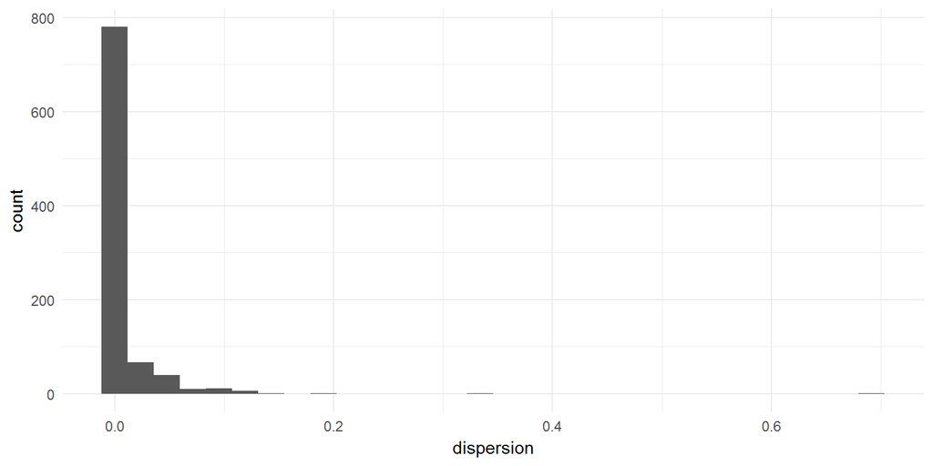

A distribuição da variável *dispersion* é bastante concentrada do lado esquerdo do gráfico. Algumas poucas exceções de valores mais altos. Talvez seja interessante considerar alguma transformação dessa variável a fim de melhor avaliar a qualidade dos resultados.

Na tabela a seguir, temos os valores para algumas estatísticas de *dispersion*.

Estatística descritiva da dispersão

| 1º Quartil | Mediana | 3º Quartil | Média | Desvio Padrão |
| --- | --- | --- | --- | --- |
| 1.4e-05 | 0.000104 | 0.002448 | 0.008622 | 0.0322126 |

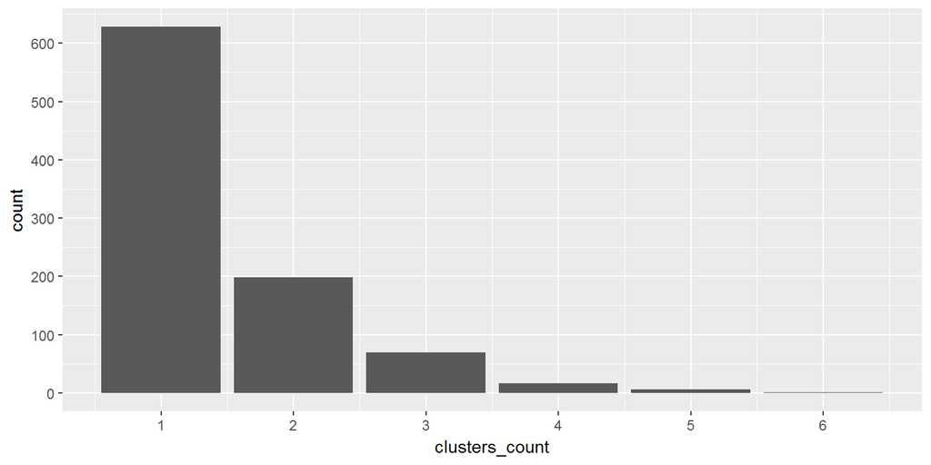

Das 1040 observações, um pouco mais de 600 ($\approx 60\%$) obtiveram apenas um *cluster* como resultado da pesquisa.

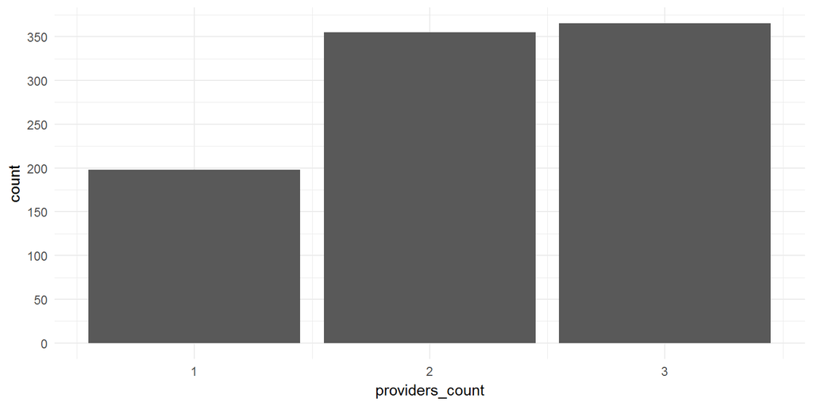

Quanto à quantidade de provedores (*providers_count*), a distribuição parece mais homogênea. Praticamente a quantidade de observações com 2 e 3 provedores foi igual. Apenas 200 ($\approx 20\%$) das observações obtiveram um único provedor.

Por fim, talvez seja interessante olhar a relação entre as três variáveis já que uma observação com boa qualidade seria aquela com baixo valor de dispersão, poucos *clusters* e alta quantidade de provedores. A princípio, espera-se que exista uma correlação entre esses resultados.

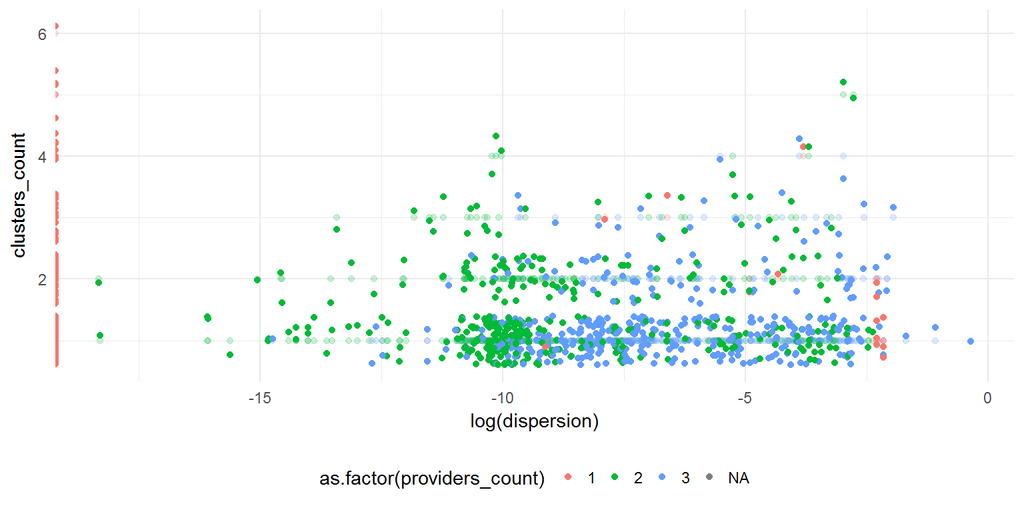

Decidi utilizar o *log* de *dispersion* a fim de evitar que os pontos ficassem muito concentrados em torno do 0. Além disso, adicionei um pouco de variação aleatória nos pontos com objetivo de não deixá-los sobrepostos uns aos outros.

## 1.3. Distribuição dos Indicadores por Município

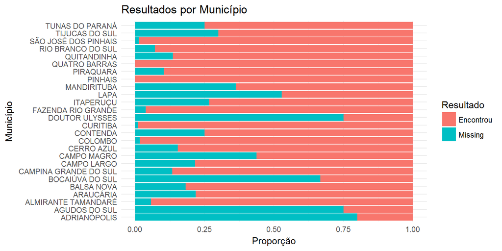

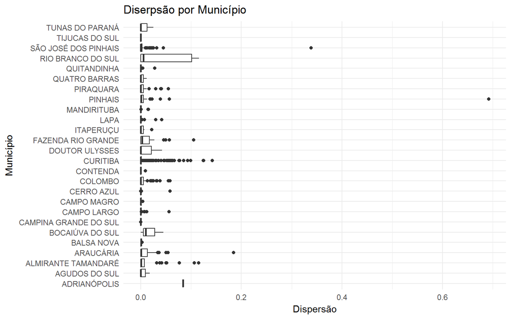

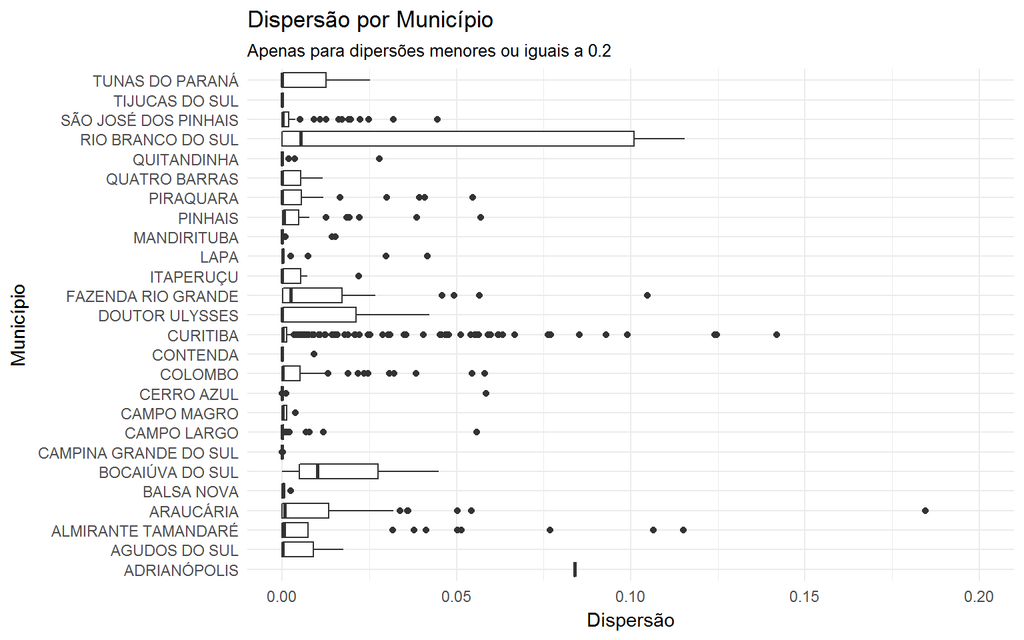

A fim de melhor visualizar a difereça entre as cidades, neste imagem limitei o gráfico para o intervalo de dispersão (0, 0.2). Aparentemente temos dois padrões de distribuição. De um lado, cidades que ficaram bem próximas do 0 (ex. Curitiba, Campina Grande do Sul, Lapa) e de cidades que com um intervalo um pouco maior (Agudos do Sul, etc).

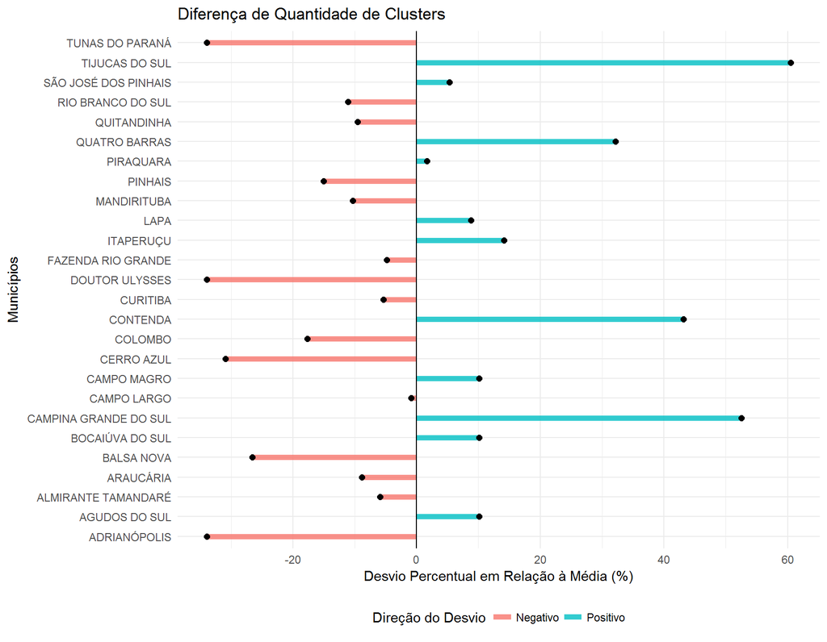

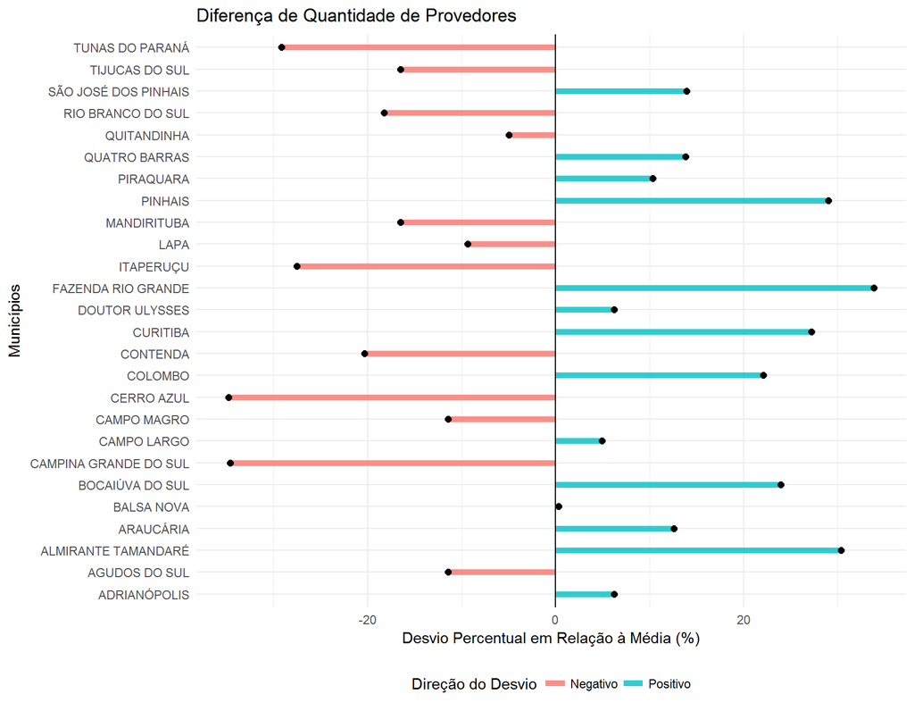

## 1.4. Mapas

Neste seção, o objetivo foi investigar como essas variáveis de qualidade (dispersão, quantidade de provedores, quantidade de clusters) se distribuem pelo espaço.

No primeiro mapa, temos a variável dispersão.

[interactive chart not shown]

No segundo mapa, temos a variável quantidade de clusters.

[interactive chart not shown]

Por fim, no terceiro mapa, temos a variável quantidade de provedores.

[interactive chart not shown]